# filter-pipe.tcl documentation

Detlef Groth, Caputh-Schwielowsee, Germany

Mär 20, 2025

filter-abc - filter-cmd - filter-dot - filter-emf - filter-eqn - filter-julia - filter-kroki - filter-mmd - filter-mtex - filter-pic/dpic - filter-pik  
filter-pipe - filter-puml - filter-rplot - filter-sqlite - filter-tcrd - filter-tcl - filter-tdot - filter-tsvg

Documentation: Pantcl filter documentation - Pantcl tutorial - Pantcl Readme - Pantcl Gui

## Name

*filter-pipe.tcl* - Filter which can be used to execute various programming languages using a pipe mechanism using the Tcl filter driver `pantcl.bin` and showing or hiding the output.

## Usage

The conversion of the Markdown documents via Pandoc should be done as follows:

```
pandoc input.md --filter pantcl.bin -s -o output.html
```

The file `filter-pipe.tcl` is not used directly but sourced automatically by the `pantcl.bin` file. If code blocks with the `.pipe` marker are found, the contents in the code block is processed via a shell pipe either using the python3, the Rscript or the octave command line application.

The following options can be given via code chunks or in the YAML header.

> - eval - should the code in the code block be evaluated, default: false/0
> - echo - should the input code been shown, default: true/1
> - pipe - the programming language to be used, either R, python, which is python3 or octave, default: python3
> - results - should the output of the command line application been shown, should be asis, show or hide, default: show
> - wait - the timeout (ms) after every code evaluation to wait for the pipe to read, try to decrease the time to get a speedup, increase of you observe output at wrong places, default: 100

To change the defaults the YAML header can be used. Here an example to change the default pipe command to R and evaluate all code chunks. Please note that you should write `eval: 1` and not(!) `eval: true`

```
 ----
 title: "filter-pipe.tcl documentation"
 author: "Detlef Groth, Caputh-Schwielowsee, Germany"
 date: 2022-01-12
 pipe:
     pipe: R
     eval: 1
 ----
```

## Examples

### Python examples

Here an example for very simple python code.

```
x=1
print(x)
y=x+1
print(y)
```

```
>>> x=1
>>> print(x)
1>>> y=x+1
>>> print(y)
2>>>
```

In contrast to the .cmd filter the code chunks are in the same session, so we can continue to add more Python code which knows about the existing variables from the session before.

Here an example declaring a function:

```
def test (x):
    return(x+1)

print(test(y))
```

```
>>> def test (x):
>>>     return(x+1)
>>>
>>> print(test(y))
3>>>
```

We can as well omit the terminal mode by setting the chunk option “terminal to false”. You will then only see the output.

```
def test2 (x):
    return(x+2)

print(test2(y))
```

```
4
```

Let’s finish the Python section with an image created with *matplotlib* (`{.pipe terminal=false results="hide"}`).

```
import matplotlib.pyplot as plt

# frequencies
ages = [2,5,70,40,30,45,50,45,43,40,44,
        60,7,13,57,18,90,77,32,21,20,40]

# setting the ranges and no. of intervals
range = (0, 100)
bins = 10

# plotting a histogram
plt.hist(ages, bins, range, color = 'skyblue',
        histtype = 'bar', rwidth = 0.8)

# x-axis label
plt.xlabel('age')
# frequency label
plt.ylabel('No. of people')
# plot title
plt.title('My histogram')

# save the file
plt.savefig('images/pyhist.png')
```

We then just display the image file using standard Markdown.

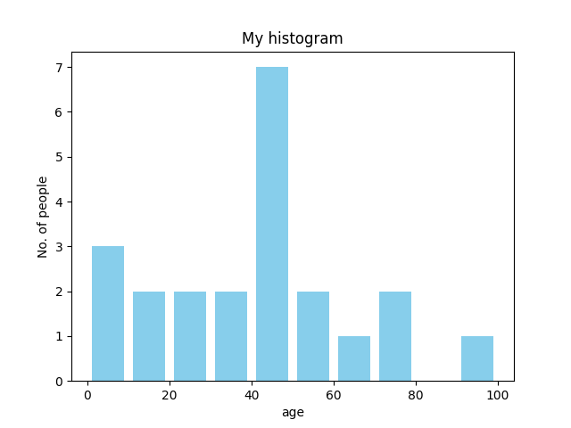

There is as well the possibility to add inline Python code to display the values of variables or the output of short python commands here an example:

```
l = [1,2,3,4]
g = [1,2,3,4,5]
print(len(l))
```

```
>>> l = [1,2,3,4]
>>> g = [1,2,3,4,5]
>>> print(len(l))
4>>>
```

```
g.append(6)
print(len(g))
```

```
>>> g.append(6)
>>> print(len(g))
6>>>
```

Let’s now display the length of the list g, g has a length of 6!

Another trial: *py 3+2=* 5? Should be five!

Let’s finish with Python code containing an error:

```
y=3
# a type
print(y00)
```

```
>>> y=3
>>> # a type
>>> print(y00)
Traceback (most recent call last):  File "<stdin>", line 1, in <module>
NameError: name 'y00' is not defined
>>>
```

Using the non-pandoc based Tcl application there is as well the comma based syntax supported, here an example (`{python terminal=FALSE,results="show",echo=TRUE}`):

```
x=1
print(x)
```

```
1
```

### R examples

````
     ```{.pipe pipe="R" results="show"}
     source("~/R/dlibs/chords.R")
     data(iris)
     png("images/testr.png")
     boxplot(iris$Sepal.Length ~ iris$Species,col=2:4)
     dev.off()
     print(2)
     1
     ```
````

```
source("~/R/dlibs/chords.R")
data(iris)
png("images/testr.png")
boxplot(iris$Sepal.Length ~ iris$Species,col=2:4)
dev.off()
print(2)
1
```

[output not shown]

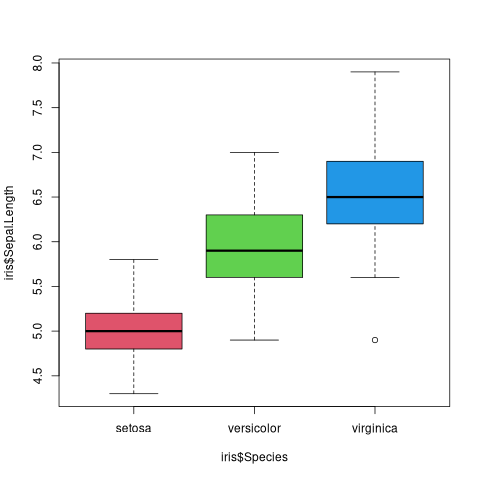

Now a table example:

```
data(mtcars)
knitr::kable(head(mtcars[, 1:4]))
```

|  | mpg | cyl | disp | hp |
| --- | --- | --- | --- | --- |
| Mazda RX4 | 21.0 | 6 | 160 | 110 |
| Mazda RX4 Wag | 21.0 | 6 | 160 | 110 |
| Datsun 710 | 22.8 | 4 | 108 | 93 |
| Hornet 4 Drive | 21.4 | 6 | 258 | 110 |
| Hornet Sportabout | 18.7 | 8 | 360 | 175 |
| Valiant | 18.1 | 6 | 225 | 105 |

The filter itself provides a few little R functions, without the need to install an additional library. To display tables, the function `df2md` converts data frames or matrices into Markdown tables. Here an example for its usage:

```
data(mtcars)
df2md(head(mtcars[, 1:4],n=4))
```

|  | mpg | cyl | disp | hp |
| --- | --- | --- | --- | --- |
| **Mazda RX4** | 21 | 6 | 160 | 110 |
| **Mazda RX4 Wag** | 21 | 6 | 160 | 110 |
| **Datsun 710** | 22.8 | 4 | 108 | 93 |
| **Hornet 4 Drive** | 21.4 | 6 | 258 | 110 |

You can as well hide the rownames or give a caption like this.

```
n = ntab('tabmt')
df2md(head(mtcars[, 1:4],n=4),rownames=FALSE,caption=sprintf("**Table %i:** mtcars data",n))
```

| mpg | cyl | disp | hp |
| --- | --- | --- | --- |
| 21 | 6 | 160 | 110 |
| 21 | 6 | 160 | 110 |
| 22.8 | 4 | 108 | 93 |
| 21.4 | 6 | 258 | 110 |

**Table 1:** mtcars data

For matrices or data frames without row names or column names just the line and columnnumbers will be displayed:

```
n = ntab('tabrn')
M=matrix(round(rnorm(100,mean=10),2),ncol=5)
df2md(head(M,n=6),caption=sprintf("**Table %i:** Matrix example",n))
```

|  | 1 | 2 | 3 | 4 | 5 |
| --- | --- | --- | --- | --- | --- |
| **1** | 10.96 | 11.38 | 9.37 | 8.56 | 9.03 |
| **2** | 9.21 | 8.68 | 11.44 | 9.04 | 9.8 |
| **3** | 9.29 | 11.39 | 10.62 | 11.12 | 9.67 |
| **4** | 9.12 | 10.2 | 10.66 | 9.67 | 9.65 |
| **5** | 9.27 | 10.53 | 8.5 | 11.92 | 10.46 |
| **6** | 10.53 | 8.38 | 11.13 | 9.9 | 10.77 |

**Table 2:** Matrix example

To allow automatic numbering and referencing figures and tables, the following 4 functions are provided:

- `nfig(label)` - to set a figure number, usually within the figure legend
- `rfig(label)` - to reference a figure using its label, usually used within paragraphs close to the figure
- `ntab(label)` - same as `nfig` but for tables
- `rtab(label)` - same as `rfig` but for tables. Here an example:

```
'``
A --> B --> C
'``
__Figure `r nfig('sample')`:__ a sample flow chart figure.

This is some text which relates to figure `r rfig('sample')`.
An non-existing like `r rfig('dummy')` is shown with NN.

For examples for tables see tables `r rtab("tabmt")` and `r rtab("tabrn")`.
```

And here the output:

```
A --> B --> C
```

**Figure 1:** a sample flow chart figure.

This is some text which relates to figure 1. An non-existing like “NN” is shown with NN.

For examples for tables see tables 1 and 2.

There is as well the possibility to display inline R code. So for instance we can use the nrow function to get the number of cars in the dataset. Using code like this:

```
    The mtchars dataset has `r nrow(mtcars)` cars!
```

The mtchars dataset has 32 cars!

Let’s now simulate an R error:

```
x=3+2
print(ls())
x
print(y)
2+3
```

```
> x=3+2
> print(ls())
 [1] "df2md"  "iris"   "lipsum" "M"      "mtcars" "n"      "nfig"   "ntab"
 [9] "rfig"   "rtab"   "x"
> x
[1] 5
> print(y)
Fehler: Objekt 'y' nicht gefunden
> 2+3
[1] 5
```

The R code blocks as well support knitr and Rmarkdown compatible chunk code options so you could say for instance instead of `{.pipe pipe="R" eval=true echo=false results=show}` also `{r eval=TRUE,echo=FALSE,results="show"}` here both examples:

Space based syntax:

```
x=1
> print(x)
[1] 1
```

And here Knitr/RMarkdown compatible syntax:

```
x=1
> print(x)
[1] 1
```

### Octave examples

```
x=1;
disp(x);
y=2;
disp(y);
```

```
octave> x=1;
QSocketNotifier: Can only be used with threads started with QThread
octave> disp(x);
(octave-gui:44526): Gtk-WARNING **: 13:59:01.700: Theme parsing error: <data>:1:0: Expected a valid selector
octave> y=2;
1
octave> disp(y);
2
octave>
```

Now let’s do a plot:

```
aux=figure('visible','off');
tx = ty = linspace (-8, 8, 41);
[xx, yy] = meshgrid (tx, ty);
r = sqrt (xx .^ 2 + yy .^ 2) + eps;
tz = sin (r) ./ r;
mesh (tx, ty, tz);
saveas(aux, 'images/mesh-octave.png', 'png');
```

```
octave> aux=figure('visible','off');
octave> tx = ty = linspace (-8, 8, 41);
octave> [xx, yy] = meshgrid (tx, ty);
octave> r = sqrt (xx .^ 2 + yy .^ 2) + eps;
octave> tz = sin (r) ./ r;
octave> mesh (tx, ty, tz);
octave> saveas(aux, 'images/mesh-octave.png', 'png');
octave>
```

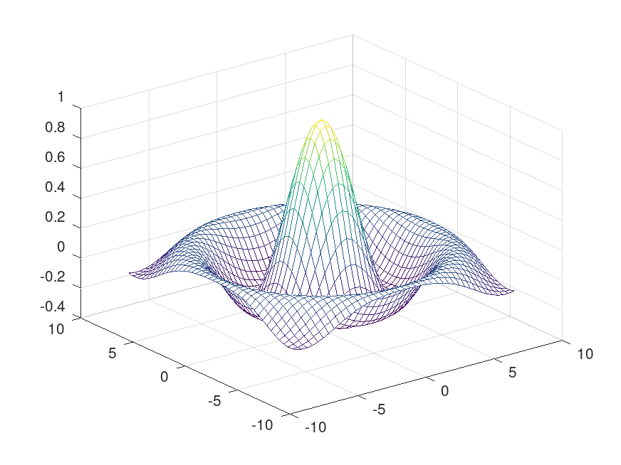

What about inline code? What is the value of y? It should be `oc disp(y)`. Hmm, not yet working.

```
z=x+y
disp(z)
```

```
octave> z=x+y
z = 3
octave> disp(z)
3
octave>
```

Let’s now do an Octave error:

```
z
disp(k)
```

```
octave> z
z = 3
octave> disp(k)
error: 'k' undefined near line 1, column 6
octave>
```

Also Octave supports as a non-pandoc filter as well the Knitr/RMarkdown compatible syntax, here an example:

```
z=x+y
disp(z)
```

```
octave> z=x+y
z = 3
octave> disp(z)
3
octave>
```

## TODO:

- support Python (done) - inline (done) - error catching (done)
- support R (done) - inline (done) - error catching (done)
- support Octave (done) - inline (not working) - error catching (done)
- support Julia??
- terminal mode on/off

## See also:

- Pantcl Readme
- Tcl filter
- Rplot filter